# ED71 Line Extention for Asthma Therapy

kohsuke maeda

2018年9月6日

# Research for the Relation VDR Signal and Asthma

These days, the resistance to Athma therapy is reported. and based on the mode of action of that resistance, Th17 cell is regarded to be one of the main factor which acquires resistance to Asthma standard therapy Symbicort.

Now in Japan, the most commonly used drug for asthma is SYMBICORT, which is promoted by Astellas and AstraZeneca.

[figure not shown]

Symbicort

Also, Th17 release many inflmmatory cytokine, such as IL17A, IL22, IL23.  
VDR signal is regarded to be responsible for the suppression of Th17 differentiation.  
Eventually, Vitamin D suppresses the Th17 subpopulation, and so suppress that resistance.

Th17 is one of the CD4 Tcell subpopulation. naive CD4 Tcell can diferrentiate into Th17. during this process, VD/VDR signal inhibits that differentiation.

ED71 is Vitamin D analogs, and approved in osteoporosis in PMDA. This was developed by Chugai Pharmaceuticals. Most of the time, Vitamin D high serum concentration will trigger the side effect of Hypercalcemia, due to that it is believed that the therapeutic window for Vitamin D therapy is so narrow. The Advantage of this analog (ED71) is resistant to CYP24A1 deconstruction, so with low serum concentration,it will show efficacy with minimum side effect.

As a conclusion, it is anticipated that ED71 combination therapy with Symbicort would be efficient. RNA-Seq data for Asthma, which is called “airway”, is now available.  
This RNA-Seq data is composed of million of Short Reads.  
We have to allign those reads with Gene Model, whch will require high PC performance.

asthma

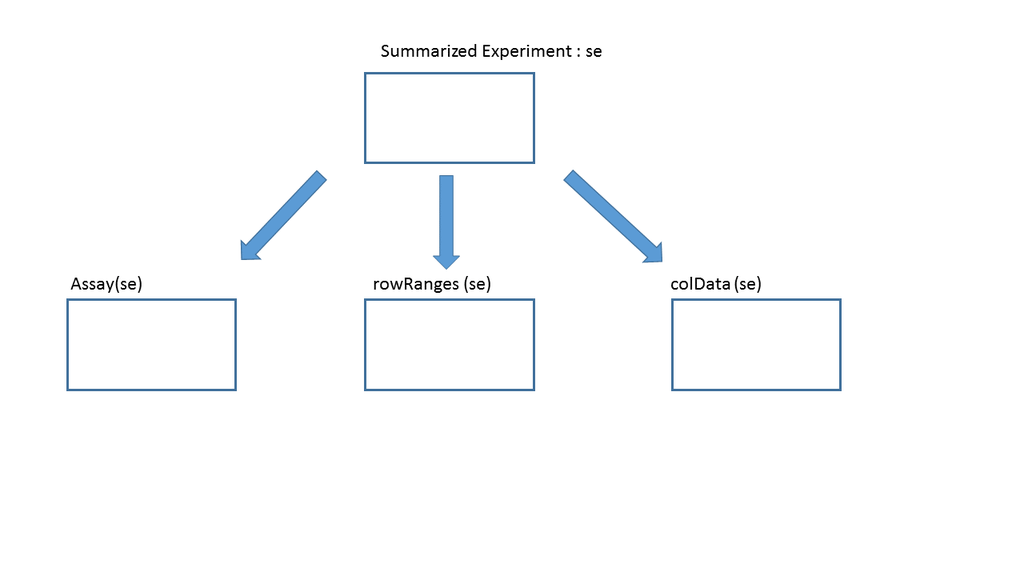

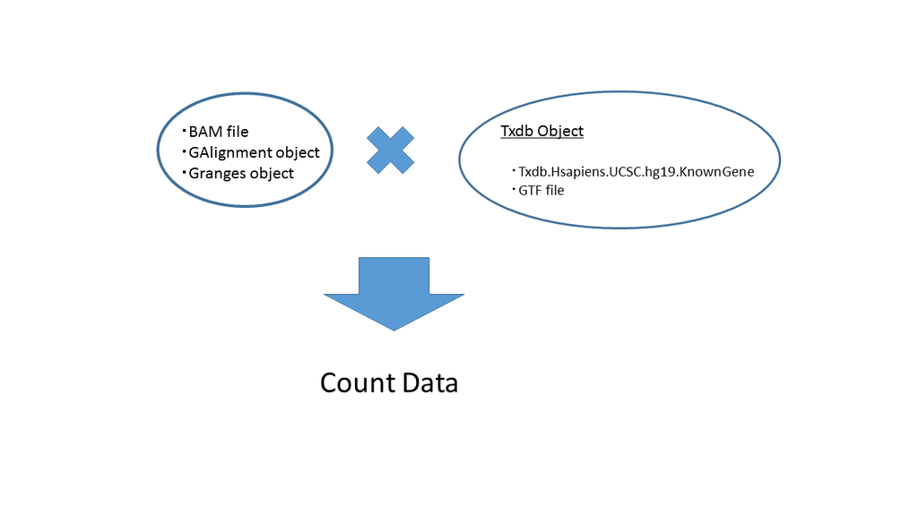

[figure not shown]

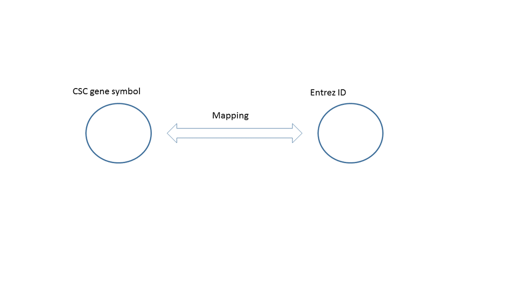